# Project: Investigate a Dataset - [Soccer]

- Introduction
- Data Wrangling
- Exploratory Data Analysis
- Conclusions

## Introduction

### Question(s) for Analysis

**Questions I want to get answers to them from anylsis of this is**

1-what the relationship between age of the players and overall rating for players?

2-what is the relationship between the body mass index and the overall rating of the players?

3-Does team win more when playing in his home? Does home team scores more goals than Away team?

4-Is there a relationship between win percentage and Pythagorean expectation?

```python
# Use this cell to set up import statements for all of the packages that you
#   plan to use.
import numpy as np
import pandas as pd
import matplotlib.pyplot as plt
import seaborn as sns
import statsmodels.formula.api as smf
% matplotlib inline

# Remember to include a 'magic word' so that your visualizations are plotted
#   inline with the notebook. See this page for more:
#   http://ipython.readthedocs.io/en/stable/interactive/magics.html
```

```python
# Upgrade pandas to use dataframe.explode() function.
!pip install --upgrade pandas==0.25.0
```

## Data Wrangling

1-take some cols from players

2-take some cols from player_attributes

3- inner join to make a table between players and players attributes

4- checking for null values

```python
# take some cols from players
players_dataset = pd.read_csv("Database_Soccer/Player.csv")
players = players_dataset[["player_api_id", "player_name", "birthday", "height", "weight"]]
print(players.head())
```

```
   player_api_id         player_name             birthday  height  weight
0         505942  Aaron Appindangoye  1992-02-29 00:00:00  182.88     187
1         155782     Aaron Cresswell  1989-12-15 00:00:00  170.18     146
2         162549         Aaron Doran  1991-05-13 00:00:00  170.18     163
3          30572       Aaron Galindo  1982-05-08 00:00:00  182.88     198
4          23780        Aaron Hughes  1979-11-08 00:00:00  182.88     154
```

```python
# take some cols from player_attributes
player_attributes_datasets = pd.read_csv("Database_Soccer/Player_Attributes.csv")
player_attributes = player_attributes_datasets[["player_api_id", "date", "overall_rating"]]
```

```python
# inner join to make a tble between players and players attributes
player_with_attr = players.merge(player_attributes, on = "player_api_id")
player_with_attr.duplicated().sum()
player_with_attr.info()
```

```
<class 'pandas.core.frame.DataFrame'>
Int64Index: 183978 entries, 0 to 183977
Data columns (total 7 columns):
player_api_id     183978 non-null int64
player_name       183978 non-null object
birthday          183978 non-null object
height            183978 non-null float64
weight            183978 non-null int64
date              183978 non-null object
overall_rating    183142 non-null float64
dtypes: float64(2), int64(2), object(3)
memory usage: 11.2+ MB
```

```python
# checking for null values
player_with_attr.isnull().sum()
```

```
player_api_id       0
player_name         0
birthday            0
height              0
weight              0
date                0
overall_rating    836
dtype: int64
```

```python
# load data from league table
league_datset = pd.read_csv("Database_Soccer/League.csv")
leagues = league_datset[["id", "name"]]
print(leagues)
```

```
       id                      name
0       1    Belgium Jupiler League
1    1729    England Premier League
2    4769            France Ligue 1
3    7809     Germany 1. Bundesliga
4   10257             Italy Serie A
5   13274    Netherlands Eredivisie
6   15722        Poland Ekstraklasa
7   17642  Portugal Liga ZON Sagres
8   19694   Scotland Premier League
9   21518           Spain LIGA BBVA
10  24558  Switzerland Super League
```

```python
# load data from team table
team_dataset = pd.read_csv("Database_Soccer/Team.csv")
teams = team_dataset[["team_api_id", "team_long_name"]]
print(teams.head())
```

```
   team_api_id     team_long_name
0         9987           KRC Genk
1         9993       Beerschot AC
2        10000   SV Zulte-Waregem
3         9994   Sporting Lokeren
4         9984  KSV Cercle Brugge
```

```python
# load data from matches table
matches_dataset = pd.read_csv("Database_Soccer/Match.csv")
# take some important columns from our point of view
matches = matches_dataset[["league_id", "season", "date", "home_team_api_id", "away_team_api_id", "home_team_goal",
                          "away_team_goal"]]
print(matches.head())
```

```
   league_id     season                 date  home_team_api_id  \
0          1  2008/2009  2008-08-17 00:00:00              9987
1          1  2008/2009  2008-08-16 00:00:00             10000
2          1  2008/2009  2008-08-16 00:00:00              9984
3          1  2008/2009  2008-08-17 00:00:00              9991
4          1  2008/2009  2008-08-16 00:00:00              7947

   away_team_api_id  home_team_goal  away_team_goal
0              9993               1               1
1              9994               0               0
2              8635               0               3
3              9998               5               0
4              9985               1               3
```

```python
# filter matches table to extrct English premier league matches only
# league_id of England Premier League is 1729
matchesEPL = matches[matches["league_id"] == 1729]
# we have 3040 match in EPL from 2008 to 2016
```

### Data Cleaning

1- remove null values and remove duplicated rows

2- changing date and birthday to dates format

3- add new column age

```python
# After discussing the structure of the data and any problems that need to be
#   cleaned, perform those cleaning steps in the second part of this section.
# cleaning the table of player with attributes
# remove null values and remove duplicated rows
player_with_attr.dropna(inplace = True)
player_with_attr.info()
player_with_attr.duplicated().sum()
```

```
<class 'pandas.core.frame.DataFrame'>
Int64Index: 183142 entries, 0 to 183977
Data columns (total 7 columns):
player_api_id     183142 non-null int64
player_name       183142 non-null object
birthday          183142 non-null object
height            183142 non-null float64
weight            183142 non-null int64
date              183142 non-null object
overall_rating    183142 non-null float64
dtypes: float64(2), int64(2), object(3)
memory usage: 11.2+ MB
```

```
0
```

```python
# cleaning EPL maches
# check for any null values n our dataset
matchesEPL.isnull().sum()
# we don't have any null values in our data
# check for duplicated rows in our data
matchesEPL.duplicated().sum()
# we don't have any duplicated values
```

```
0
```

```python
# changing date and birthday to dates format
player_with_attr["birthday"] = pd.to_datetime(player_with_attr["birthday"], format='%Y/%m/%d %H:%M:%S')
player_with_attr["date"] = pd.to_datetime(player_with_attr["date"], format='%Y/%m/%d %H:%M:%S')
# add new column age
player_with_attr["age"] = player_with_attr["date"] - player_with_attr["birthday"]
player_with_attr["age"] =player_with_attr["age"].astype('<m8[Y]')
player_with_attr.info()
print(player_with_attr.head(20))
```

```
<class 'pandas.core.frame.DataFrame'>
Int64Index: 183142 entries, 0 to 183977
Data columns (total 8 columns):
player_api_id     183142 non-null int64
player_name       183142 non-null object
birthday          183142 non-null datetime64[ns]
height            183142 non-null float64
weight            183142 non-null int64
date              183142 non-null datetime64[ns]
overall_rating    183142 non-null float64
age               183142 non-null float64
dtypes: datetime64[ns](2), float64(3), int64(2), object(1)
memory usage: 12.6+ MB
    player_api_id         player_name   birthday  height  weight       date  \
0          505942  Aaron Appindangoye 1992-02-29  182.88     187 2016-02-18
```

[output cut: 41 more lines]

```python
# the number of the players
player_with_attr.nunique()
# we have 11060 player
```

```
player_api_id     11060
player_name       10848
birthday           5762
height               20
weight               50
date                197
overall_rating       61
age                  37
dtype: int64
```

```python
# I will determine which teams win and which tie or lose
# we will add result of the match to our table as H if home team win and A if away team win and as D in draw
matchesEPL["result"] = np.where(matchesEPL["home_team_goal"] > matchesEPL["away_team_goal"], "H",
                               np.where(matchesEPL["home_team_goal"]< matchesEPL["away_team_goal"], "A", "D"))
print(matchesEPL.head())
```

```
      league_id     season                 date  home_team_api_id  \
1728       1729  2008/2009  2008-08-17 00:00:00             10260
1729       1729  2008/2009  2008-08-16 00:00:00              9825
1730       1729  2008/2009  2008-08-16 00:00:00              8472
1731       1729  2008/2009  2008-08-16 00:00:00              8654
1732       1729  2008/2009  2008-08-17 00:00:00             10252

      away_team_api_id  home_team_goal  away_team_goal result
1728             10261               1               1      D
1729              8659               1               0      H
1730              8650               0               1      A
1731              8528               2               1      H
1732              8456               4               2      H
```

```python
# we will add a value for matches if win will gain 1 if draw will gain .5 else will gain 0
matchesEPL['hwinvalue'] = np.where(matchesEPL['result']=='H',1,np.where(matchesEPL['result']=='D',.5,0))
matchesEPL['awinvalue']=np.where(matchesEPL['result']=='A',1,np.where(matchesEPL['result']=='D',.5,0))
# adding count to every match to reprsent games that every team played
matchesEPL["count"] = 1
```

```python
# making sepearte dataframes for home teams and away teams to analyze performance
# make home teams df
Enghometeams = matchesEPL.groupby(["home_team_api_id"])['count','hwinvalue',
                                                       'home_team_goal','away_team_goal'].sum().reset_index()

# now we will merge team id with their names to get more insights
Enghome = Enghometeams.merge(teams, left_on = "home_team_api_id", right_on = "team_api_id")
Enghome = Enghome.drop(["home_team_api_id", "team_api_id"], 1)
Enghome = Enghome.rename(columns={'team_long_name':'team','count':'matches_home',
                                  'home_team_goal':'my_goals_home','away_team_goal':'A_goals_against_me'})

# make away team table
Engawayteams = matchesEPL.groupby('away_team_api_id')['count','awinvalue', 'home_team_goal','away_team_goal'].sum().reset_index()


# now we will merge team id with their names to get more insights
Engaway = Engawayteams.merge(teams, left_on = "away_team_api_id", right_on = "team_api_id")
Engaway = Engaway.drop(["away_team_api_id", "team_api_id"], 1)
Engaway = Engaway.rename(columns={'team_long_name':'team','count':'matchesAway',
                                  'home_team_goal':'H_goals_against_me','away_team_goal':'mygoals_away'})
```

```python
# merge home team with away team
EPL = pd.merge(Enghome, Engaway, on = ['team'])
# reorder my columns
EPL = EPL[['team','matches_home', 'hwinvalue', 'my_goals_home', 'A_goals_against_me',
           'matchesAway', 'awinvalue', 'H_goals_against_me','mygoals_away']]
```

## Exploratory Data Analysis

### Research Question 1 (The relationship between the age of the player and the overall rating for players and top 100 players )

1- looking to relationship between age of player and overall rating 2-make one graph showing age and overall rating of the players of the top 100 players

```python
player_with_attr["BMI"] = np.array(player_with_attr["weight"])*0.453592 / (np.array(player_with_attr["height"])/100)**2
```

```python
# Use this, and more code cells, to explore your data. Don't forget to add
#   Markdown cells to document your observations and findings.
player_with_attr.sort_values(by = "overall_rating", ascending = False, inplace = True)
```

```python
# getting the top 100 players
top = (pd.unique(player_with_attr['player_name']))[0:101]
top_100 = pd.DataFrame(top, columns = ['player_name'])
print(top_100)
```

```
              player_name
0            Lionel Messi
1       Cristiano Ronaldo
2        Gianluigi Buffon
3            Wayne Rooney
4          Gregory Coupet
5          Xavi Hernandez
6           Thierry Henry
7        Alessandro Nesta
8           Iker Casillas
9         Fabio Cannavaro
10             Ronaldinho
11         Andres Iniesta
12             John Terry
13         Radamel Falcao
```

[output cut: 49 more lines]

```python
# merge between my dataframe and the top 100
player_with_attr_top = player_with_attr.merge(top_100, on ="player_name")
print(player_with_attr_top)
```

```
      player_api_id           player_name   birthday  height  weight  \
0             30981          Lionel Messi 1987-06-24  170.18     159
1             30981          Lionel Messi 1987-06-24  170.18     159
2             30981          Lionel Messi 1987-06-24  170.18     159
3             30981          Lionel Messi 1987-06-24  170.18     159
4             30981          Lionel Messi 1987-06-24  170.18     159
5             30981          Lionel Messi 1987-06-24  170.18     159
6             30981          Lionel Messi 1987-06-24  170.18     159
7             30981          Lionel Messi 1987-06-24  170.18     159
8             30981          Lionel Messi 1987-06-24  170.18     159
9             30981          Lionel Messi 1987-06-24  170.18     159
10            30981          Lionel Messi 1987-06-24  170.18     159
11            30981          Lionel Messi 1987-06-24  170.18     159
12            30981          Lionel Messi 1987-06-24  170.18     159
13            30981          Lionel Messi 1987-06-24  170.18     159
```

[output cut: 112 more lines]

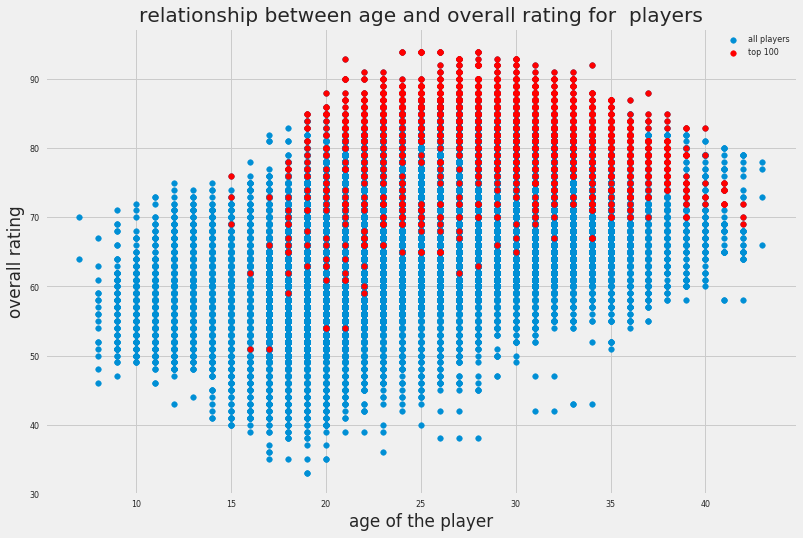

```python
# make a scatter plot showing relationship between age and overall rating
# for top 100 players
plt.style.use('fivethirtyeight')
fig = plt.figure(figsize=(12,8))
plt.scatter(player_with_attr["age"],
          player_with_attr["overall_rating"], label = "all players")
plt.scatter(player_with_attr_top["age"], player_with_attr_top["overall_rating"], color = "red", label = "top 100")
plt.title("relationship between age and overall rating for  players")
plt.xlabel("age of the player")
plt.ylabel("overall rating")
plt.legend()
plt.show()
```

```python
def make_summary(var1, var2, data):
    summary = smf.ols(formula = 'var1 ~ var2', data=data).fit()
    return summary.summary()
```

```python
make_summary(player_with_attr.age, player_with_attr.overall_rating, player_with_attr)
```

OLS Regression Results

| Dep. Variable: | var1 | R-squared: | 0.144 |
| --- | --- | --- | --- |
| Model: | OLS | Adj. R-squared: | 0.144 |
| Method: | Least Squares | F-statistic: | 3.085e+04 |
| Date: | Mon, 24 Jan 2022 | Prob (F-statistic): | 0.00 |
| Time: | 20:25:00 | Log-Likelihood: | -5.3050e+05 |
| No. Observations: | 183142 | AIC: | 1.061e+06 |
| Df Residuals: | 183140 | BIC: | 1.061e+06 |
| Df Model: | 1 |  |  |
| Covariance Type: | nonrobust |  |  |

|  | coef | std err | t | P>\|t\| | [0.025 | 0.975] |
| --- | --- | --- | --- | --- | --- | --- |
| Intercept | 7.6840 | 0.100 | 76.606 | 0.000 | 7.487 | 7.881 |
| var2 | 0.2555 | 0.001 | 175.628 | 0.000 | 0.253 | 0.258 |

| Omnibus: | 3438.524 | Durbin-Watson: | 1.383 |
| --- | --- | --- | --- |
| Prob(Omnibus): | 0.000 | Jarque-Bera (JB): | 3635.072 |
| Skew: | 0.344 | Prob(JB): | 0.00 |
| Kurtosis: | 3.048 | Cond. No. | 676. |

```python
pyth_lm = smf.ols(formula = 'age ~ overall_rating', data=player_with_attr).fit()
pyth_lm.summary()
```

OLS Regression Results

| Dep. Variable: | age | R-squared: | 0.144 |
| --- | --- | --- | --- |
| Model: | OLS | Adj. R-squared: | 0.144 |
| Method: | Least Squares | F-statistic: | 3.085e+04 |
| Date: | Mon, 24 Jan 2022 | Prob (F-statistic): | 0.00 |
| Time: | 19:12:27 | Log-Likelihood: | -5.3050e+05 |
| No. Observations: | 183142 | AIC: | 1.061e+06 |
| Df Residuals: | 183140 | BIC: | 1.061e+06 |
| Df Model: | 1 |  |  |
| Covariance Type: | nonrobust |  |  |

|  | coef | std err | t | P>\|t\| | [0.025 | 0.975] |
| --- | --- | --- | --- | --- | --- | --- |
| Intercept | 7.6840 | 0.100 | 76.606 | 0.000 | 7.487 | 7.881 |
| overall_rating | 0.2555 | 0.001 | 175.628 | 0.000 | 0.253 | 0.258 |

| Omnibus: | 3438.524 | Durbin-Watson: | 1.383 |
| --- | --- | --- | --- |
| Prob(Omnibus): | 0.000 | Jarque-Bera (JB): | 3635.072 |
| Skew: | 0.344 | Prob(JB): | 0.00 |
| Kurtosis: | 3.048 | Cond. No. | 676. |

1- Calculating BMI by using height and weight of every palyer using weight/ height^2

2- looking to the relationship between overall rating of the player and BMi

```python
# Continue to explore the data to address your additional research
# calculate BMI for players and transform from pound to kg and from cm to meter
player_with_attr["BMI"] = np.array(player_with_attr["weight"])*0.453592 / (np.array(player_with_attr["height"])/100)**2
```

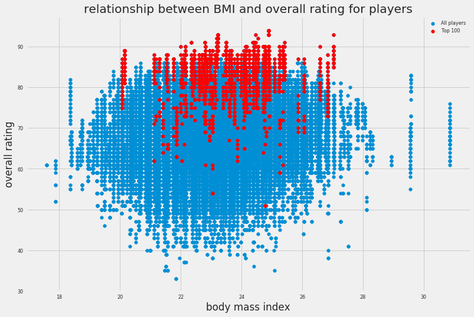

```python
# make a scatter plot showing relationship between BMI and overall rating
plt.style.use('fivethirtyeight')
fig = plt.figure(figsize=(12,8))
plt.scatter(player_with_attr["BMI"],
          player_with_attr["overall_rating"], label = "All players")
plt.scatter(player_with_attr_top["BMI"], player_with_attr_top["overall_rating"], color = "red", label = "Top 100")
plt.title("relationship between BMI and overall rating for players")
plt.xlabel("body mass index")
plt.ylabel("overall rating")
plt.legend()
plt.show()
```

```python
make_summary(player_with_attr.BMI,player_with_attr.overall_rating,player_with_attr)
```

OLS Regression Results

| Dep. Variable: | var1 | R-squared: | 0.010 |
| --- | --- | --- | --- |
| Model: | OLS | Adj. R-squared: | 0.010 |
| Method: | Least Squares | F-statistic: | 1919. |
| Date: | Mon, 24 Jan 2022 | Prob (F-statistic): | 0.00 |
| Time: | 20:26:10 | Log-Likelihood: | -3.1192e+05 |
| No. Observations: | 183142 | AIC: | 6.238e+05 |
| Df Residuals: | 183140 | BIC: | 6.239e+05 |
| Df Model: | 1 |  |  |
| Covariance Type: | nonrobust |  |  |

|  | coef | std err | t | P>\|t\| | [0.025 | 0.975] |
| --- | --- | --- | --- | --- | --- | --- |
| Intercept | 21.7921 | 0.030 | 716.633 | 0.000 | 21.733 | 21.852 |
| var2 | 0.0193 | 0.000 | 43.806 | 0.000 | 0.018 | 0.020 |

| Omnibus: | 2570.063 | Durbin-Watson: | 1.361 |
| --- | --- | --- | --- |
| Prob(Omnibus): | 0.000 | Jarque-Bera (JB): | 3953.794 |
| Skew: | 0.149 | Prob(JB): | 0.00 |
| Kurtosis: | 3.655 | Cond. No. | 676. |

### Research Question 3 (Does team win more when playing in his home? Does home team scores more goals than Away team?)

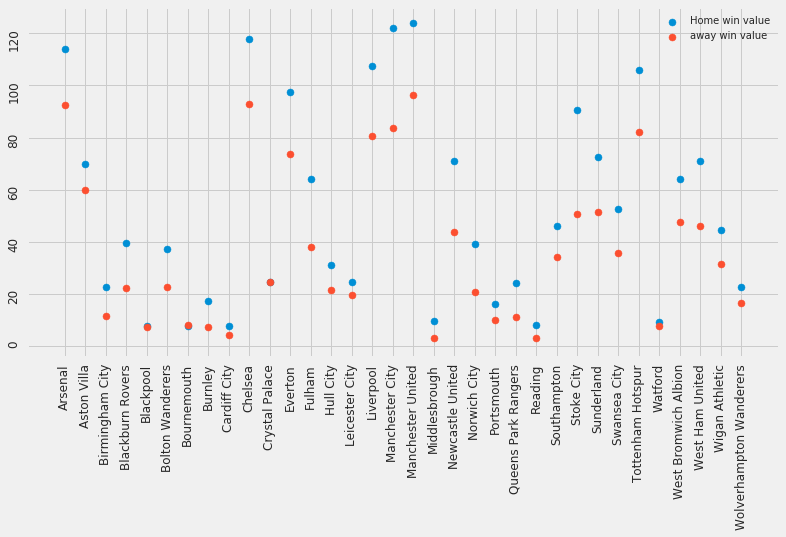

```python
# a scatter plot for teams when they play in their homes and when they play Away
fig, ax = plt.subplots(figsize=(12, 6))
ax.tick_params(rotation=90, labelsize=12)
ax.scatter(x = EPL["team"], y = EPL["hwinvalue"], label = "Home win value")
ax.scatter(x = EPL["team"], y = EPL["awinvalue"], label ="away win value" )
plt.legend()
plt.show()
```

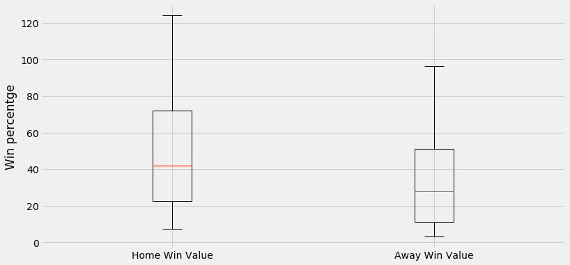

```python
# A box plot for teams when they play home and Away
fig, ax = plt.subplots(figsize=(12, 6))
ax.boxplot([EPL["hwinvalue"],EPL["awinvalue"]])
ax.set_xticklabels(["Home Win Value", "Away Win Value"])
ax.set_ylabel("Win percentge")
plt.show()
```

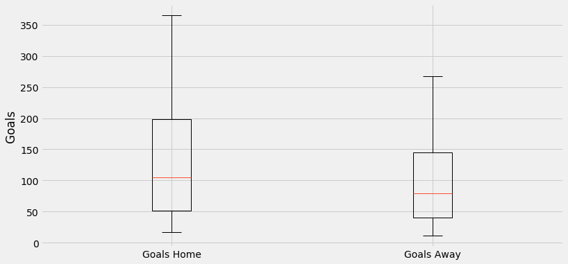

```python
# Does Home team scores more goals than away team
fig, ax = plt.subplots(figsize=(12, 6))
ax.boxplot([EPL["my_goals_home"],EPL["mygoals_away"]])
ax.set_xticklabels(["Goals Home", "Goals Away"])
ax.set_ylabel("Goals")
plt.show()
```

### Research Question 4 (Is there a relationship between win percentage and Pythagorean expectation?)

win percentage(wpc) calculate the percentage of wins of games(wins value/ Games played) pythagorean takes my goals in the opponent and the goals of the opponent against me it has a formula and it can predicts the performance of the teams in the future

```python
EPL['W'] = EPL['hwinvalue'].values + EPL['awinvalue'].values
EPL['Games_played'] = EPL['matches_home'].values +EPL ['matchesAway'].values
EPL['Goals'] = EPL['my_goals_home'].values +EPL['mygoals_away'].values
EPL['GoalsA'] = EPL['H_goals_against_me'].values +EPL['A_goals_against_me'].values
EPL['wpc'] = EPL['W'].values/EPL['Games_played'].values
EPL['pyth'] = EPL['Goals'].values**2/(EPL['Goals'].values**2 + EPL['GoalsA'].values**2)
```

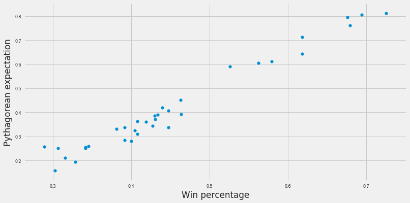

```python
fig, ax = plt.subplots(figsize=(12, 6))
ax.scatter(x = EPL["wpc"], y = EPL["pyth"])
ax.set_xlabel("Win percentage")
ax.set_ylabel("Pythagorean expectation")
plt.show()
```

```python
# Run the regression
make_summary(EPL.wpc,EPL.pyth,EPL)
```

OLS Regression Results

| Dep. Variable: | var1 | R-squared: | 0.968 |
| --- | --- | --- | --- |
| Model: | OLS | Adj. R-squared: | 0.967 |
| Method: | Least Squares | F-statistic: | 961.2 |
| Date: | Mon, 24 Jan 2022 | Prob (F-statistic): | 1.92e-25 |
| Time: | 20:27:44 | Log-Likelihood: | 82.309 |
| No. Observations: | 34 | AIC: | -160.6 |
| Df Residuals: | 32 | BIC: | -157.6 |
| Df Model: | 1 |  |  |
| Covariance Type: | nonrobust |  |  |

|  | coef | std err | t | P>\|t\| | [0.025 | 0.975] |
| --- | --- | --- | --- | --- | --- | --- |
| Intercept | 0.1901 | 0.009 | 20.391 | 0.000 | 0.171 | 0.209 |
| var2 | 0.6288 | 0.020 | 31.003 | 0.000 | 0.587 | 0.670 |

| Omnibus: | 3.525 | Durbin-Watson: | 1.970 |
| --- | --- | --- | --- |
| Prob(Omnibus): | 0.172 | Jarque-Bera (JB): | 2.153 |
| Skew: | -0.489 | Prob(JB): | 0.341 |
| Kurtosis: | 3.749 | Cond. No. | 6.31 |

## Conclusions

from graph that showing repaltionship between overall rating and age that the highest rating for players was in the range from 25 to 30 years and then rating decrease.

from second graph that showing a relationship between bmi and rating most of players have an index ratio between 22 to 25.

there is a big relation between wins and home of the team, the team scores more goals when playing in his home.

there is a relation between the win percentage and the goals that team scores and the goals against him

### Limitations

I can't figure out the standards to evalute players and maybe the players do good after 30

## Submitting your Project

```python
from subprocess import call
call(['python', '-m', 'nbconvert', 'Investigate_a_Dataset.ipynb'])
```

```
0
```